# Exploratory Data Analysis

Elodie Kwan and Katia Voltz

2022-04-26

Our very first steps once we received the **German Credit data** was to dig into it and get to know the observations and features we were going to work with.

## Get to know the data

The title of the dataset is *German credit data* and the name of the file is **GermanCredit.cvs**.

As said in the introduction, the German Credit data has data on 1000 observations on past credit applicants and it is described by 30 attributes. Each applicant is rated as “Good” or “Bad” credit (encoded as 1 and 0 respectively in the **RESPONSE** variable).

We looked at the attribute Information :

Table continues below

| OBS. | CHK_ACCT | DURATION | HISTORY | NEW_CAR | USED_CAR | FURNITURE | RADIO.TV | EDUCATION | RETRAINING | AMOUNT | SAV_ACCT |
| --- | --- | --- | --- | --- | --- | --- | --- | --- | --- | --- | --- |
| Min. : 1.0 | Min. :0.000 | Min. : 4.0 | Min. :0.000 | Min. :0.000 | Min. :0.000 | Min. :0.000 | Min. :0.00 | Min. :-1.000 | Min. :0.000 | Min. : 250 | Min. :0.000 |
| 1st Qu.: 250.8 | 1st Qu.:0.000 | 1st Qu.:12.0 | 1st Qu.:2.000 | 1st Qu.:0.000 | 1st Qu.:0.000 | 1st Qu.:0.000 | 1st Qu.:0.00 | 1st Qu.: 0.000 | 1st Qu.:0.000 | 1st Qu.: 1366 | 1st Qu.:0.000 |
| Median : 500.5 | Median :1.000 | Median :18.0 | Median :2.000 | Median :0.000 | Median :0.000 | Median :0.000 | Median :0.00 | Median : 0.000 | Median :0.000 | Median : 2320 | Median :0.000 |
| Mean : 500.5 | Mean :1.577 | Mean :20.9 | Mean :2.545 | Mean :0.234 | Mean :0.103 | Mean :0.181 | Mean :0.28 | Mean : 0.048 | Mean :0.097 | Mean : 3271 | Mean :1.105 |
| 3rd Qu.: 750.2 | 3rd Qu.:3.000 | 3rd Qu.:24.0 | 3rd Qu.:4.000 | 3rd Qu.:0.000 | 3rd Qu.:0.000 | 3rd Qu.:0.000 | 3rd Qu.:1.00 | 3rd Qu.: 0.000 | 3rd Qu.:0.000 | 3rd Qu.: 3972 | 3rd Qu.:2.000 |
| Max. :1000.0 | Max. :3.000 | Max. :72.0 | Max. :4.000 | Max. :1.000 | Max. :1.000 | Max. :1.000 | Max. :1.00 | Max. : 1.000 | Max. :1.000 | Max. :18424 | Max. :4.000 |

Table continues below

| EMPLOYMENT | INSTALL_RATE | MALE_DIV | MALE_SINGLE | MALE_MAR_or_WID | CO.APPLICANT | GUARANTOR | PRESENT_RESIDENT | REAL_ESTATE | PROP_UNKN_NONE | AGE | OTHER_INSTALL |
| --- | --- | --- | --- | --- | --- | --- | --- | --- | --- | --- | --- |
| Min. :0.000 | Min. :1.000 | Min. :0.00 | Min. :0.000 | Min. :0.000 | Min. :0.000 | Min. :0.000 | Min. :1.000 | Min. :0.000 | Min. :0.000 | Min. : 19.0 | Min. :0.000 |
| 1st Qu.:2.000 | 1st Qu.:2.000 | 1st Qu.:0.00 | 1st Qu.:0.000 | 1st Qu.:0.000 | 1st Qu.:0.000 | 1st Qu.:0.000 | 1st Qu.:2.000 | 1st Qu.:0.000 | 1st Qu.:0.000 | 1st Qu.: 27.0 | 1st Qu.:0.000 |
| Median :2.000 | Median :3.000 | Median :0.00 | Median :1.000 | Median :0.000 | Median :0.000 | Median :0.000 | Median :3.000 | Median :0.000 | Median :0.000 | Median : 33.0 | Median :0.000 |
| Mean :2.384 | Mean :2.973 | Mean :0.05 | Mean :0.548 | Mean :0.092 | Mean :0.041 | Mean :0.053 | Mean :2.845 | Mean :0.282 | Mean :0.154 | Mean : 35.6 | Mean :0.186 |
| 3rd Qu.:4.000 | 3rd Qu.:4.000 | 3rd Qu.:0.00 | 3rd Qu.:1.000 | 3rd Qu.:0.000 | 3rd Qu.:0.000 | 3rd Qu.:0.000 | 3rd Qu.:4.000 | 3rd Qu.:1.000 | 3rd Qu.:0.000 | 3rd Qu.: 42.0 | 3rd Qu.:0.000 |
| Max. :4.000 | Max. :4.000 | Max. :1.00 | Max. :1.000 | Max. :1.000 | Max. :1.000 | Max. :2.000 | Max. :4.000 | Max. :1.000 | Max. :1.000 | Max. :125.0 | Max. :1.000 |

| RENT | OWN_RES | NUM_CREDITS | JOB | NUM_DEPENDENTS | TELEPHONE | FOREIGN | RESPONSE |
| --- | --- | --- | --- | --- | --- | --- | --- |
| Min. :0.000 | Min. :0.000 | Min. :1.000 | Min. :0.000 | Min. :1.000 | Min. :0.000 | Min. :0.000 | Min. :0.0 |
| 1st Qu.:0.000 | 1st Qu.:0.000 | 1st Qu.:1.000 | 1st Qu.:2.000 | 1st Qu.:1.000 | 1st Qu.:0.000 | 1st Qu.:0.000 | 1st Qu.:0.0 |
| Median :0.000 | Median :1.000 | Median :1.000 | Median :2.000 | Median :1.000 | Median :0.000 | Median :0.000 | Median :1.0 |
| Mean :0.179 | Mean :0.713 | Mean :1.407 | Mean :1.904 | Mean :1.155 | Mean :0.404 | Mean :0.037 | Mean :0.7 |
| 3rd Qu.:0.000 | 3rd Qu.:1.000 | 3rd Qu.:2.000 | 3rd Qu.:2.000 | 3rd Qu.:1.000 | 3rd Qu.:1.000 | 3rd Qu.:0.000 | 3rd Qu.:1.0 |
| Max. :1.000 | Max. :1.000 | Max. :4.000 | Max. :3.000 | Max. :2.000 | Max. :1.000 | Max. :1.000 | Max. :1.0 |

We noticed that the variable **EDUCATION** has a minimum value of ‘-1’ but it should be ‘0’ since there are only 2 levels (0 and 1). Indeed, the observation 37 indicate a value of ‘-1’ for **EDUCATION**. We notice another strange value, in the variable **GUARANTOR**, the maximum value is of ‘2’ while it does not mean anything in our data set.

After discussion with the Banker, he gave us the correct values to these 2 mistakes. Observation 37 of **EDUCATION** and observation 234 of **GUARANTOR** should be equal to 1. We corrected these two values.

We also saw that the variable **AGE** has a maximum of 125. This is strange because it is very unlikely that someone lives to the age of 125. We talked to the banker again and he confirmed our doubts by telling us that a mistake has been made. At the observation 537, the correct age of the client is 75 years old. He asked us to correct this value in our data set.

After looking at the different attributes, we concluded that there were no missing values.

The response variable is identified as being the column named ‘**Response**’ and it apprears to be the last column on the data.

It is a dummy variable with 0/1.

1. 0 : No, the credit rating is bad.
2. 1 : Yes, the credit rating is good.

We had to make sure that the class of the variables are correct. As described above, all the variables are defined as *integer* but we know that we should have numerical and categorical variables in our dataset. Therefore, we have to transform the class of some of them.

```
## 'data.frame':    1000 obs. of  32 variables:
##  $ OBS.            : Factor w/ 1000 levels "1","2","3","4",..: 1 2 3 4 5 6 7 8 9 10 ...
##  $ CHK_ACCT        : Factor w/ 4 levels "0","1","2","3": 1 2 4 1 1 4 4 2 4 2 ...
##  $ DURATION        : num  6 48 12 42 24 36 24 36 12 30 ...
##  $ HISTORY         : Factor w/ 5 levels "0","1","2","3",..: 5 3 5 3 4 3 3 3 3 5 ...
##  $ NEW_CAR         : Factor w/ 2 levels "0","1": 1 1 1 1 2 1 1 1 1 2 ...
##  $ USED_CAR        : Factor w/ 2 levels "0","1": 1 1 1 1 1 1 1 2 1 1 ...
##  $ FURNITURE       : Factor w/ 2 levels "0","1": 1 1 1 2 1 1 2 1 1 1 ...
##  $ RADIO.TV        : Factor w/ 2 levels "0","1": 2 2 1 1 1 1 1 1 2 1 ...
##  $ EDUCATION       : Factor w/ 2 levels "0","1": 1 1 2 1 1 2 1 1 1 1 ...
##  $ RETRAINING      : Factor w/ 2 levels "0","1": 1 1 1 1 1 1 1 1 1 1 ...
##  $ AMOUNT          : num  1169 5951 2096 7882 4870 ...
##  $ SAV_ACCT        : Factor w/ 5 levels "0","1","2","3",..: 5 1 1 1 1 5 3 1 4 1 ...
##  $ EMPLOYMENT      : Factor w/ 5 levels "0","1","2","3",..: 5 3 4 4 3 3 5 3 4 1 ...
##  $ INSTALL_RATE    : num  4 2 2 2 3 2 3 2 2 4 ...
```

[output cut: 18 more lines]

The binomial data are set as factors and the others as numerical.

We then described the variables one more time and we should get better results.

```
## German_credit
##
##  32  Variables      1000  Observations
## --------------------------------------------------------------------------------
## OBS.
##        n  missing distinct
##     1000        0     1000
##
## lowest : 1    2    3    4    5   , highest: 996  997  998  999  1000
## --------------------------------------------------------------------------------
## CHK_ACCT
##        n  missing distinct
##     1000        0        4
##
## Value          0     1     2     3
## Frequency    274   269    63   394
## Proportion 0.274 0.269 0.063 0.394
## --------------------------------------------------------------------------------
## DURATION
##        n  missing distinct     Info     Mean      Gmd      .05      .10
##     1000        0       33    0.985     20.9    12.98        6        9
##      .25      .50      .75      .90      .95
##       12       18       24       36       48
##
## lowest :  4  5  6  7  8, highest: 47 48 54 60 72
## --------------------------------------------------------------------------------
## HISTORY
##        n  missing distinct
##     1000        0        5
##
## lowest : 0 1 2 3 4, highest: 0 1 2 3 4
##
## Value          0     1     2     3     4
## Frequency     40    49   530    88   293
## Proportion 0.040 0.049 0.530 0.088 0.293
## --------------------------------------------------------------------------------
## NEW_CAR
##        n  missing distinct
##     1000        0        2
##
```

[output cut: 209 more lines]

```
##        n  missing distinct
##     1000        0        2
##
## Value          0     1
## Frequency    963    37
## Proportion 0.963 0.037
## --------------------------------------------------------------------------------
## RESPONSE
##        n  missing distinct
##     1000        0        2
##
## Value        0   1
## Frequency  300 700
## Proportion 0.3 0.7
## --------------------------------------------------------------------------------
```

Table continues below

| rows | columns | discrete_columns | continuous_columns | all_missing_columns |
| --- | --- | --- | --- | --- |
| 1000 | 32 | 26 | 6 | 0 |

| total_missing_values | complete_rows | total_observations | memory_usage |
| --- | --- | --- | --- |
| 0 | 1000 | 32000 | 237424 |

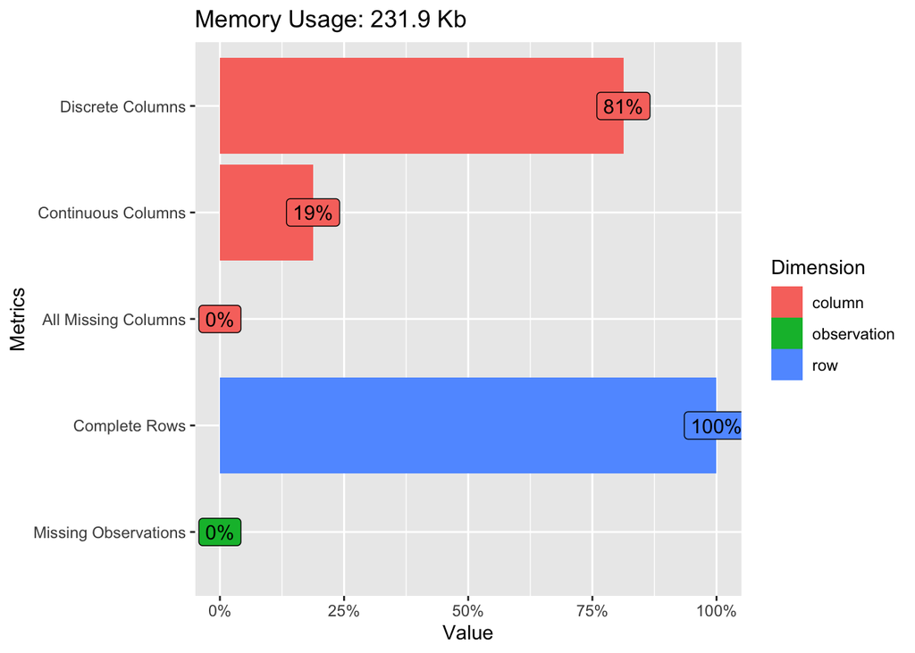

The plot helps us to see the percentage of continuous variable, the percentage of discrete variables and whether or not some observations are missing.

### Visualization of the data

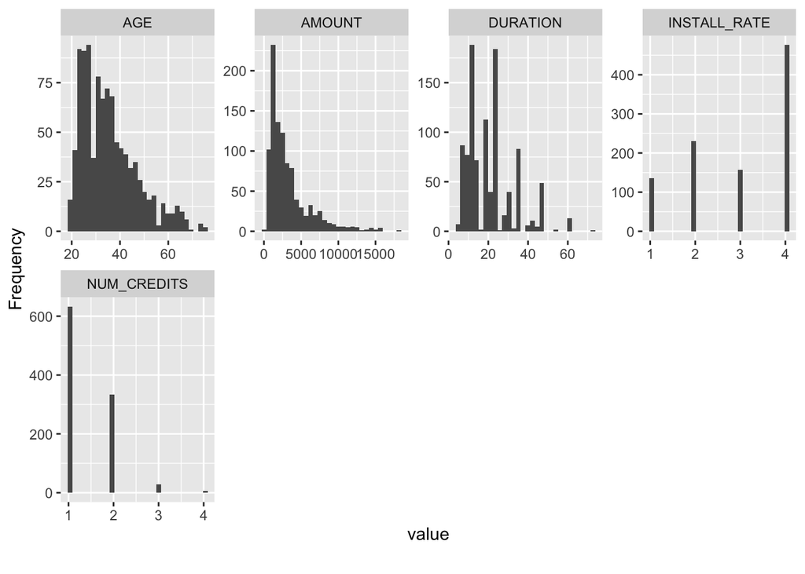

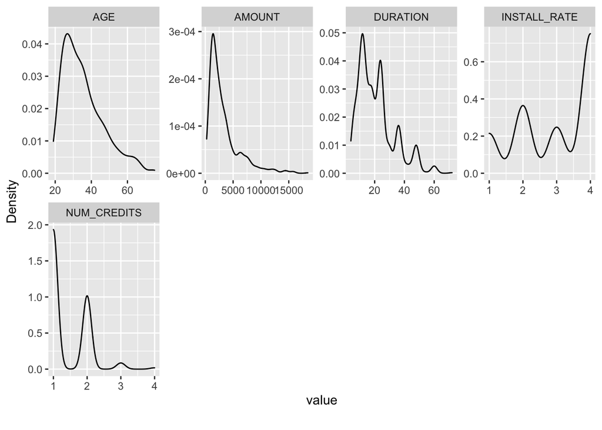

Our first notice is that the data are not really normally distributed. Some of them are right-tailed.

We can look at the tails and outliers more carefully through boxplots.

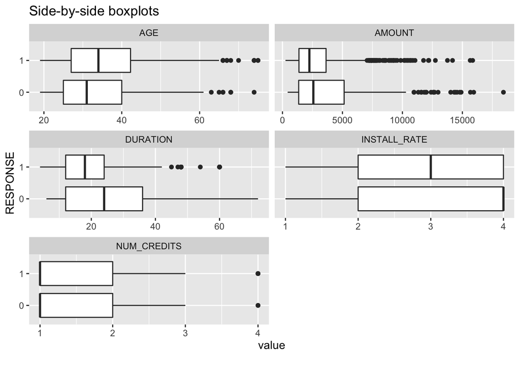

This seems not to be disturbing. It makes sense that only a few people has a big credit amount. However it seems that the ‘bad’ clients tends to ask for bigger credit amount than ‘good’ clients.

Then, we made some barplots of the categorical variables (appendix A).

A general summary can be done.

|  | No | Variable | Stats / Values | Freqs (% of Valid) | Graph | text.graph | Valid | Missing |
| --- | --- | --- | --- | --- | --- | --- | --- | --- |
| 1 | 1 | OBS.\\\n[factor] | 1\\. 1\\\n2\\. 2\\\n3\\. 3\\\n4\\. 4\\\n5\\. 5\\\n6\\. 6\\\n7\\. 7\\\n8\\. 8\\\n9\\. 9\\\n10\\. 10\\\n[ 990 others ] | \\ 1 ( 0.1%)\\\n\\ 1 ( 0.1%)\\\n\\ 1 ( 0.1%)\\\n\\ 1 ( 0.1%)\\\n\\ 1 ( 0.1%)\\\n\\ 1 ( 0.1%)\\\n\\ 1 ( 0.1%)\\\n\\ 1 ( 0.1%)\\\n\\ 1 ( 0.1%)\\\n\\ 1 ( 0.1%)\\\n\\990 (99.0%) |  | \\ \n \\ \n \\ \n \\ \n \\ \n \\ \n \\ \n \\ \n \\ \n \\ \nIIIIIIIIIIIIIIIIIII | 1000\\\n(100.0%) | 0\\\n(0.0%) |
| 2 | 2 | CHK_ACCT\\\n[factor] | 1\\. 0\\\n2\\. 1\\\n3\\. 2\\\n4\\. 3 | \\274 (27.4%)\\\n\\269 (26.9%)\\\n\\ 63 ( 6.3%)\\\n\\394 (39.4%) |  | IIIII \\ \nIIIII \\ \nI \\ \nIIIIIII | 1000\\\n(100.0%) | 0\\\n(0.0%) |
| 3 | 3 | DURATION\\\n[numeric] | Mean (sd) : 20.9 (12.1)\\\nmin < med < max:\\\n4 < 18 < 72\\\nIQR (CV) : 12 (0.6) | 33 distinct values |  | \\ \\ \\ \\ :\\\n\\ \\ : :\\\n. : :\\\n: : : \\ \\ .\\\n: : : : : . : | 1000\\\n(100.0%) | 0\\\n(0.0%) |
| 4 | 4 | HISTORY\\\n[factor] | 1\\. 0\\\n2\\. 1\\\n3\\. 2\\\n4\\. 3\\\n5\\. 4 | \\ 40 ( 4.0%)\\\n\\ 49 ( 4.9%)\\\n\\530 (53.0%)\\\n\\ 88 ( 8.8%)\\\n\\293 (29.3%) |  | \\ \n \\ \nIIIIIIIIII \\ \nI \\ \nIIIII | 1000\\\n(100.0%) | 0\\\n(0.0%) |
| 5 | 5 | NEW_CAR\\\n[factor] | 1\\. 0\\\n2\\. 1 | \\766 (76.6%)\\\n\\234 (23.4%) |  | IIIIIIIIIIIIIII \\ \nIIII | 1000\\\n(100.0%) | 0\\\n(0.0%) |
| 6 | 6 | USED_CAR\\\n[factor] | 1\\. 0\\\n2\\. 1 | \\897 (89.7%)\\\n\\103 (10.3%) |  | IIIIIIIIIIIIIIIII \\ \nII | 1000\\\n(100.0%) | 0\\\n(0.0%) |
| 7 | 7 | FURNITURE\\\n[factor] | 1\\. 0\\\n2\\. 1 | \\819 (81.9%)\\\n\\181 (18.1%) |  | IIIIIIIIIIIIIIII \\ \nIII | 1000\\\n(100.0%) | 0\\\n(0.0%) |
| 8 | 8 | RADIO.TV\\\n[factor] | 1\\. 0\\\n2\\. 1 | \\720 (72.0%)\\\n\\280 (28.0%) |  | IIIIIIIIIIIIII \\ \nIIIII | 1000\\\n(100.0%) | 0\\\n(0.0%) |
| 9 | 9 | EDUCATION\\\n[factor] | 1\\. 0\\\n2\\. 1 | \\950 (95.0%)\\\n\\ 50 ( 5.0%) |  | IIIIIIIIIIIIIIIIIII \\ \nI | 1000\\\n(100.0%) | 0\\\n(0.0%) |
| 10 | 10 | RETRAINING\\\n[factor] | 1\\. 0\\\n2\\. 1 | \\903 (90.3%)\\\n\\ 97 ( 9.7%) |  | IIIIIIIIIIIIIIIIII \\ \nI | 1000\\\n(100.0%) | 0\\\n(0.0%) |

[output cut: 22 more lines]

#### Correlation Analysis :

Correlation plot between continuous variables :

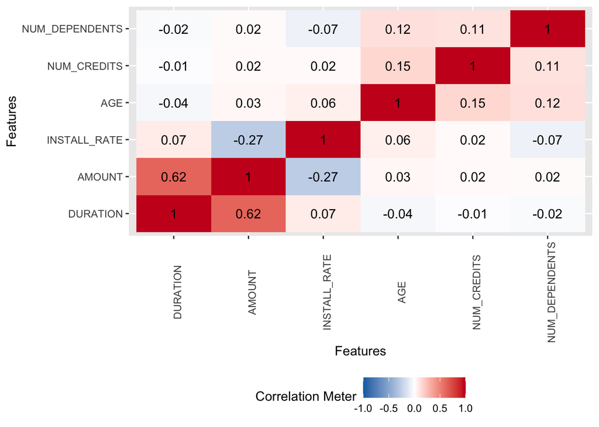

There are little correlation between the continuous variables. We can notice that there is a correlation of 62% between the variable **DURATION** and **AMOOUNT**. This makes sense and is known by the bankers that the bigger the amount of credit, the longer the duration of the credit in months will last.

Correlation plot between categorical variables :

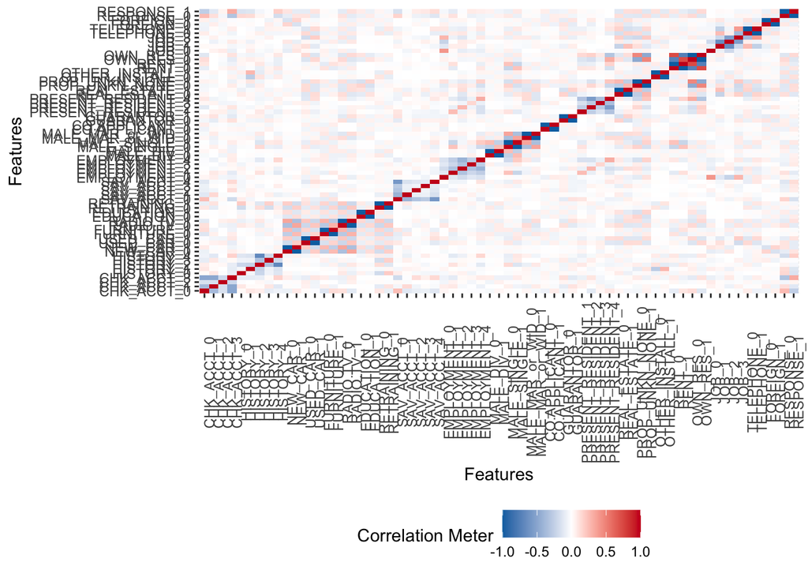

It is difficult to look at the correlation since there are a lot of variables on the graph. We can still see higher correlation between **RESPONSE 1**:

- and people that do not check their account (CHK_ACCT_3)
- and people that have a critical historical account (HISTORY_4)
- and the variable *REAL_ESTATE* (REAL_ESTATE)
- and applicant that does not have their own property (PROP_UNKN_NONE_0)
- and applicant that have their own residence (OWN_RES_1)

We can also see some correlation between **RESPONSE 0**:

- and people that have a checking account status < 0 DM (CHK_ACCT_0)
- and people that have an average balance in savings account < 100 DM (SAV_ACCT_0)
- and the variable *REAL_ESTATE* (REAL_ESTATE)

#### Principal Component Analysis Exploration:

It is good to perform a PCA Exploration in order to reduce the dimensions or/and see which variables to select.

We start by selecting the numerical values because the PCA only works on numerical variables.

```
## Importance of components:
##                           PC1    PC2    PC3    PC4    PC5     PC6
## Standard deviation     1.2873 1.1208 1.0443 0.9318 0.9193 0.53164
## Proportion of Variance 0.2762 0.2094 0.1818 0.1447 0.1409 0.04711
## Cumulative Proportion  0.2762 0.4856 0.6673 0.8120 0.9529 1.00000
```

From the PCA summary we can see 4 principal components should be taken into account in order to explain approximately 81% of the variation of the data.

#### Eigenvalue analysis:

```
##       eigenvalue variance.percent cumulative.variance.percent
## Dim.1  1.6570953        27.618256                    27.61826
## Dim.2  1.2562810        20.938016                    48.55627
## Dim.3  1.0906419        18.177365                    66.73364
## Dim.4  0.8682109        14.470181                    81.20382
## Dim.5  0.8451277        14.085462                    95.28928
## Dim.6  0.2826431         4.710719                   100.00000
```

Then from this eigenvalues table, we know that we need to choose 3 dimensions because the first 3 dimensions are higher than the value 1.

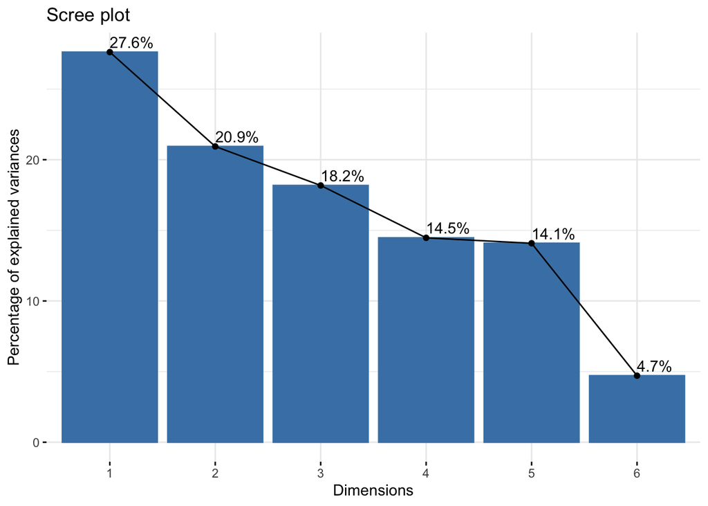

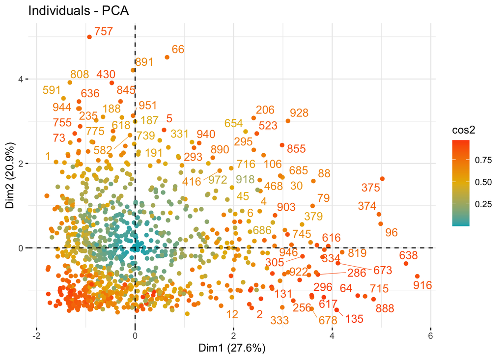

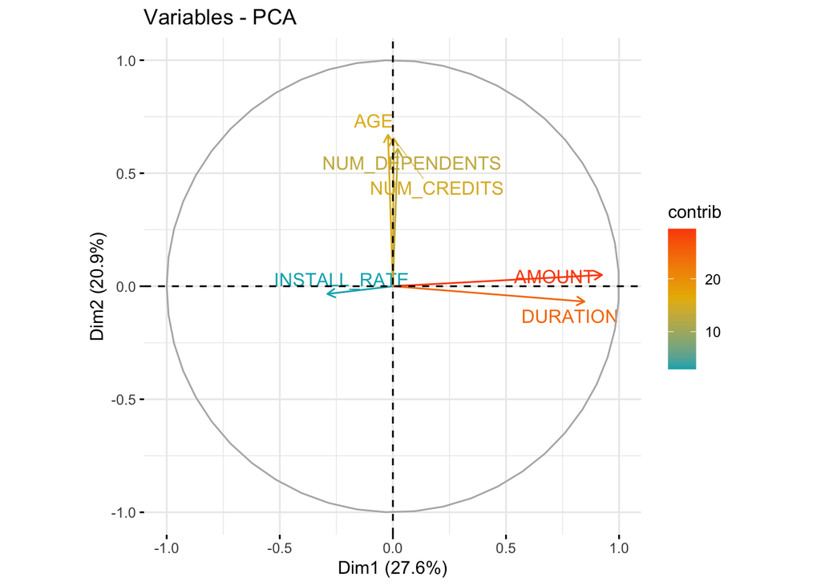

From this circle of correlations, we see that :

- The first principal component PC1 is strongly positively correlated with the variables **AMOUNT** and **DURATION**. So the larger PC1, the larger these features. It is also a little bit negatively correlated with **INSTALL_RATE**.
- The second principal component PC2 is strongly positively correlated with **AGE**, **NUM_DEPENDENTS** and **NUM_CREDITS**.

From this biplot, we can see some characteristics of the observations.

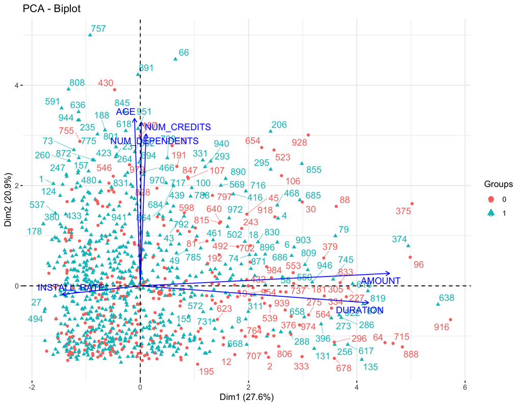

Here, we can see the distribution of the response variables (0-1) according to the reduced dimension. What we can observe, is that the Bad credits: 0, look a little bit more positively correlated ot dimension 1. Therefore, more correlated to Amount and Duration. Compared to Good Credits, it looks positively correlated to dimesion 2; **AGE**, **NUM_CREDITS**, **NUM_DEPENDENTS**.

After having cleaned the dataset and looked at all the different features, we created a new dataset that contains our modifications in order to use it for our analysis.